# Staatsoper Hamburg - Stück: Richard Strauss | Ariadne auf Naxos

[figure not shown]

Mi 29.01.2025, 19.00 - 21.10 Uhr | Großes Haus

[figure not shown]

[figure not shown]

# Ariadne auf Naxos

**Einführung um 18.20 Uhr**

„Es handelt sich um ein simples und ungeheueres Lebensproblem: das der Treue“, so beschreibt Hugo von Hofmannsthal in einem Brief an Richard Strauss den Kern ihrer dritten gemeinsamen Oper Ariadne auf Naxos. Zu leben bedeute nicht beharren und festhalten wollen an Verlorenem. Wer leben will, müsse loslassen, vergessen, über sich selber hinwegkommen – sich immerzu verwandeln. Das erlebt in diesem Werk ein junger Opernkomponist, der sich mit den eigensinnigen Wünschen seines Auftraggebers konfrontiert sieht; ebenso wie die Protagonistin seiner Oper, Ariadne, die verlassen von ihrem Geliebten, Theseus, nur noch den Tod erwartet. Doch es kommt anders… Strauss und Hofmannsthal lassen die Gegensätze aufeinanderprallen: Tragödie und Komödie, Unterhaltungsmusik und große Oper, Spiel und Ernst. So vollzieht sich in der Spiegelung von Kunst und Leben, zwischen Blick und Blick das uns allen unergründliche Geheimnis der Verwandlung.  
Musikalische Leitung: Kent Nagano  
Inszenierung und Bühne: Dmitri Tcherniakov  
Kostüme: Elena Zaytseva  
Licht: Gleb Filshtinsky  
Dramaturgie: Angela Beuerle, Michael Sangkuhl, Tatiana Werestchagina

Altersempfehlung: Ab 16 Jahren/Klasse 11

In deutscher Sprache mit deutschen und englischen Übertiteln

Ort: Großes Haus, Dammtorstraße 28, 20354 Hamburg  
Preise: 6,00 EUR bis 109,00 EUR

[figure not shown]

#### Impressionen

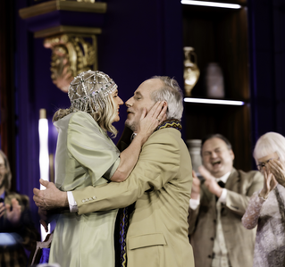

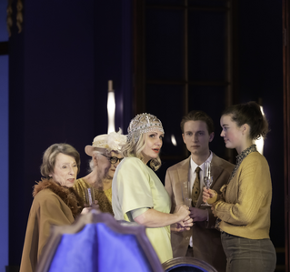

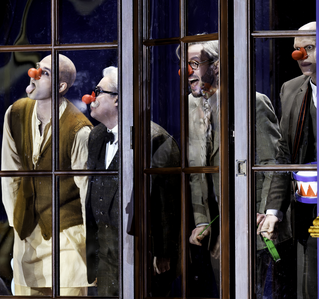

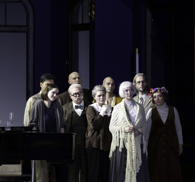

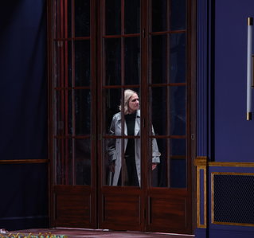

[figure not shown]